# Image_analysis_Flowers

**Loading the required packages**

```python
%pip install keras
%pip install tensorflow
import tensorflow as tf
import keras
import math

from tensorflow.keras.optimizers.schedules import ExponentialDecay
from tensorflow.keras.utils import load_img,img_to_array,array_to_img
from tensorflow.keras.optimizers import Adam

from keras.models import Sequential
from keras.layers.core import Flatten, Dense, Dropout
from keras.layers.convolutional import Convolution2D, MaxPooling2D, ZeroPadding2D
from keras.wrappers.scikit_learn import KerasClassifier

import numpy as np
from matplotlib import pyplot as plt
import matplotlib.cm as cm
from keras.models import Model
from tensorflow.keras.preprocessing import image
from tensorflow.keras.preprocessing.image import ImageDataGenerator

from keras.applications.vgg16 import VGG16, preprocess_input
from sklearn.metrics import classification_report, confusion_matrix

#from sklearn.model_selection import KFold, RepeatedKFold, StratifiedKFold, RepeatedStratifiedKFold,GridSearchCV
```

**Setting a random seed to get consistent results**

```python
np.random.seed(123)
```

**Reading the images**

```python
train_data_gen = ImageDataGenerator(rescale=1./255,
                                    rotation_range=40,
                                    width_shift_range=0.2,
                                    height_shift_range=0.2,
                                    shear_range=0.2,
                                    zoom_range=0.2,
                                    horizontal_flip=True,
                                    fill_mode='constant',
                                    vertical_flip=True)

train_data = train_data_gen.flow_from_directory(directory="/content/drive/MyDrive/train",target_size=(224,224),batch_size=342)
test_data_gen = ImageDataGenerator(rescale=1/.255)
test_data = test_data_gen.flow_from_directory(directory="/content/drive/MyDrive/test", target_size=(224,224),batch_size=142)
```

```
Found 342 images belonging to 2 classes.
Found 142 images belonging to 2 classes.
```

**Assigning the labels and the images as separate numpy arrays**

```python
train_x,train_y = train_data.next()
test_x,test_y = test_data.next()
```

**Viewing the shape of the training dataset**

```python
train_x.shape
```

```
(342, 224, 224, 3)
```

**Assigning the train and test data labels to Labels and Labels_test**

```python
Labels = train_data.labels
Labels_test = test_data.labels
```

**Lets load the pretrained model**

```python
VGG16 = VGG16(weights='imagenet',include_top = False, input_shape = (224,224,3))
```

```
Downloading data from https://storage.googleapis.com/tensorflow/keras-applications/vgg16/vgg16_weights_tf_dim_ordering_tf_kernels_notop.h5
```

```python
VGG16.summary()
```

**Making all layers non-trainable**

```python
for layer in VGG16.layers:
  layer.trainable = False

VGG16.summary()
```

**Adding a flatten, dense and classification layer to the existing VGG16 pretrained model**

```python
from tensorflow.keras import layers, models
from tensorflow.keras.regularizers import l2


flat1 = Flatten()(VGG16.layers[-1].output)
class1 = Dense(1024, activation='relu',
               kernel_initializer = 'uniform',
                kernel_regularizer=l2(l2=0.000001))(flat1)

output = Dense(2, activation='softmax')(class1)
# define new model
model = Model(inputs=VGG16.inputs, outputs=output)

model.summary()
```

**Setting up hyperparameters**

```python
epochs = 25
batch_size = 342
verbose = False,
learning_rate = 0.0003
```

**Optimizer, learning rate and momentum** Code used from this kaggle notebook: https://www.kaggle.com/code/epeterson17/few-shot-learning-of-rice-leaf-diseases

```python
np.random.seed(123)

steps_per_epoch = math.ceil(len(train_x) / batch_size)
third_of_total_steps = math.floor(100 * steps_per_epoch / 3)

# Make and compile the model.

model.compile(optimizer=Adam(
            learning_rate=ExponentialDecay(
                learning_rate,
                decay_steps=third_of_total_steps,
                decay_rate=0.1,
                staircase=True
            )
        ),
        loss="binary_crossentropy",
        metrics=["accuracy"]
    )


model.summary
```

```
<bound method Model.summary of <keras.engine.functional.Functional object at 0x7f10b482c0d0>>
```

```python
callback = tf.keras.callbacks.EarlyStopping(monitor='loss', patience=5)
```

```python
history = model.fit(train_x,train_y,
          validation_split=0.2,
          batch_size=batch_size,epochs=epochs,
          callbacks=[callback])
```

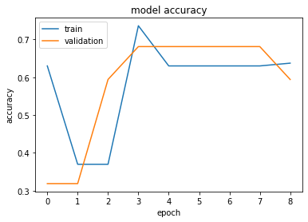

```python
#plot the training and validation accuracy and loss at each epoch
plt.plot(history.history['accuracy'])
plt.plot(history.history['val_accuracy'])
plt.title('model accuracy')
plt.ylabel('accuracy')
plt.xlabel('epoch')
plt.legend(['train', 'validation'], loc='upper left')
plt.show()
```

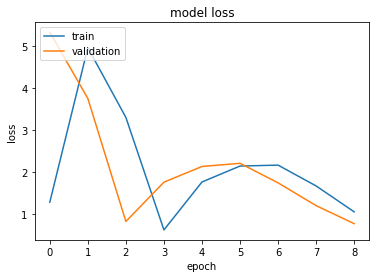

```python
#plot the training and validation accuracy and loss at each epoch
plt.plot(history.history['loss'])
plt.plot(history.history['val_loss'])
plt.title('model loss')
plt.ylabel('loss')
plt.xlabel('epoch')
plt.legend(['train', 'validation'], loc='upper left')
plt.show()
```

**Create a confusion matrix to see how our model did**

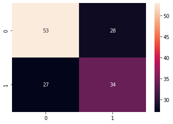

```python
import seaborn as sns

predict_test = model.predict(test_x)
predict_test = np.argmax(predict_test, axis=1)

test_labels = np.argmax(test_y,axis=1)

test_labels.shape

cm = confusion_matrix(test_labels, predict_test)

sns.heatmap(cm, annot=True)  ### 0 is Deserts ## 1 is Plains

plt.savefig("Figure S2",format="svg",dpi=300)
```

**Compute metrics**

```python
#importing accuracy_score, precision_score, recall_score, f1_score
from sklearn.metrics import accuracy_score, precision_score, recall_score, f1_score
print('\nAccuracy: {:.2f}\n'.format(accuracy_score(test_labels, predict_test)))

print('Micro Precision: {:.2f}'.format(precision_score(test_labels, predict_test, average='micro')))
print('Micro Recall: {:.2f}'.format(recall_score(test_labels, predict_test, average='micro')))
print('Micro F1-score: {:.2f}\n'.format(f1_score(test_labels, predict_test, average='micro')))

print('Macro Precision: {:.2f}'.format(precision_score(test_labels, predict_test, average='macro')))
print('Macro Recall: {:.2f}'.format(recall_score(test_labels, predict_test, average='macro')))
print('Macro F1-score: {:.2f}\n'.format(f1_score(test_labels, predict_test, average='macro')))

print('Weighted Precision: {:.2f}'.format(precision_score(test_labels, predict_test, average='weighted')))
print('Weighted Recall: {:.2f}'.format(recall_score(test_labels, predict_test, average='weighted')))
print('Weighted F1-score: {:.2f}'.format(f1_score(test_labels, predict_test, average='weighted')))

#from sklearn.metrics import classification_report
print('\nClassification Report\n')
print(classification_report(test_labels, predict_test, target_names=['Deserts','Plains']))
```

```
Accuracy: 0.61

Micro Precision: 0.61
Micro Recall: 0.61
Micro F1-score: 0.61

Macro Precision: 0.61
Macro Recall: 0.61
Macro F1-score: 0.61

Weighted Precision: 0.61
Weighted Recall: 0.61
Weighted F1-score: 0.61

Classification Report

              precision    recall  f1-score   support

     Deserts       0.66      0.65      0.66        81
      Plains       0.55      0.56      0.55        61

    accuracy                           0.61       142
   macro avg       0.61      0.61      0.61       142
weighted avg       0.61      0.61      0.61       142
```

**Determine which image to use amongst the ones from the Plains**

```python
img_path = "/content/drive/MyDrive/test/Plains/10.png"

img = image.load_img(img_path, target_size=(224, 224))

img_array = image.img_to_array(img)
img_batch = np.expand_dims(img_array, axis=0)

img_batch

prediction_plains = model.predict(img_batch)

prediction_plains
```

```
array([[3.7439603e-09, 1.0000000e+00]], dtype=float32)
```

**Determine which image to use amongst the ones from the Deserts**

```python
img_path = "/content/drive/MyDrive/test/Deserts/1.png"

img = image.load_img(img_path, target_size=(224, 224))

img_array = image.img_to_array(img)
img_batch = np.expand_dims(img_array, axis=0)

img_batch

prediction_deserts = model.predict(img_batch)

prediction_deserts
```

```
array([[1.0000000e+00, 1.1185502e-12]], dtype=float32)
```

**Extracting two layers and visualizing how the Neural Network learns, desert image**

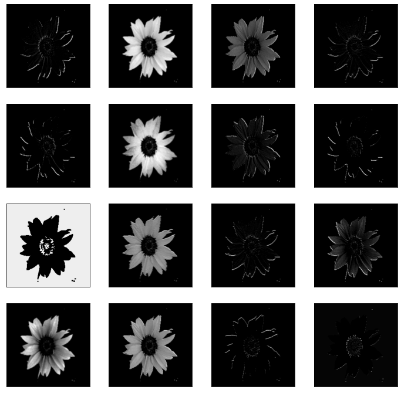

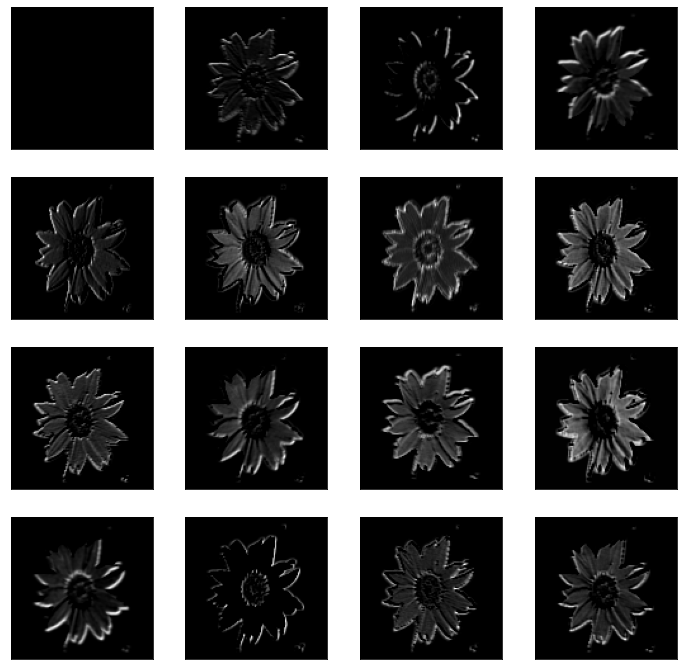

```python
layers_VGG16 = VGG16.layers

conv_layer_index = [1,4]  # These are the layers we want to visualize # creating an index for them

outputs = [VGG16.layers[i].output for i in conv_layer_index] ### extracting these layers

VGG16_shallow = Model(inputs=VGG16.inputs, outputs=outputs) ## a model containing only the Conv layers 1,2,4,5,7


img = load_img('/content/drive/MyDrive/test/Deserts/1.png', target_size=(224, 224)) #VGG user 224 as input

# convert the image to an array
img = img_to_array(img)
# expand dimensions to match the shape of model input
img = np.expand_dims(img, axis=0)

# Generate feature output by predicting on the input image
feature_output = VGG16_shallow.predict(img)


columns = 4
rows = 4
for ftr in feature_output:
    #pos = 1
    fig=plt.figure(figsize=(12, 12))
    for i in range(1, columns*rows +1):
        fig =plt.subplot(rows, columns, i)
        fig.set_xticks([])  #Turn off axis
        fig.set_yticks([])
        plt.imshow(ftr[0, :, :, i-1], cmap='gray')
        #pos += 1
    plt.show()
    plt.savefig("image.png.png")
```

**Extracting two layers and visualizing how the Neural Network learns, plains image**

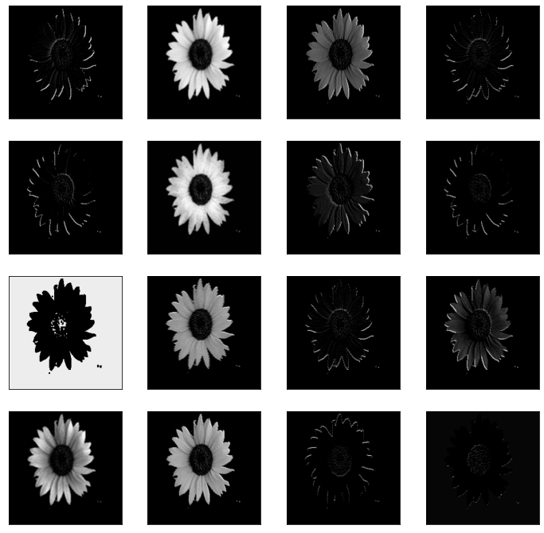

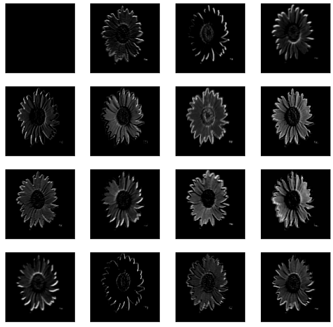

```python
layers_VGG16 = VGG16.layers

conv_layer_index = [1,4]  # These are the layers we want to visualize # creating an index for them

outputs = [VGG16.layers[i].output for i in conv_layer_index] ### extracting these layers

VGG16_shallow = Model(inputs=VGG16.inputs, outputs=outputs) ## a model containing only the Conv layers 1,2,4,5,7


img = load_img('/content/drive/MyDrive/test/Plains/10.png', target_size=(224, 224)) #VGG user 224 as input

# convert the image to an array
img = img_to_array(img)
# expand dimensions to match the shape of model input
img = np.expand_dims(img, axis=0)

# Generate feature output by predicting on the input image
feature_output = VGG16_shallow.predict(img)

columns = 4
rows = 4
for ftr in feature_output:
    #pos = 1
    fig=plt.figure(figsize=(12, 12))
    for i in range(1, columns*rows +1):
        fig =plt.subplot(rows, columns, i)
        fig.set_xticks([])  #Turn off axis
        fig.set_yticks([])
        plt.imshow(ftr[0, :, :, i-1], cmap='gray')
        #pos += 1
    plt.show()
```

**GRAD CAM ON THIS IMAGE**

```python
preprocess_input = keras.applications.vgg16.preprocess_input
decode_predictions = keras.applications.vgg16.decode_predictions

## last conv layer of the model

last_conv_layer_name = "block5_conv3"   ### Extracting the last conv layer name
```

**Defining some helper function to create the Gradcam heatmap (Taken directly** **from the keras blog**: https://keras.io/examples/vision/grad_cam/

```python
def make_gradcam_heatmap(img_array, model, last_conv_layer_name, pred_index=None):
    # First, we create a model that maps the input image to the activations
    # of the last conv layer as well as the output predictions
    grad_model = tf.keras.models.Model(
        [model.inputs], [model.get_layer(last_conv_layer_name).output, model.output]
    )

    # Then, we compute the gradient of the top predicted class for our input image
    # with respect to the activations of the last conv layer
    with tf.GradientTape() as tape:
        last_conv_layer_output, preds = grad_model(img_array)
        if pred_index is None:
            pred_index = tf.argmax(preds[0])
        class_channel = preds[:, pred_index]

    # This is the gradient of the output neuron (top predicted or chosen)
    # with regard to the output feature map of the last conv layer
    grads = tape.gradient(class_channel, last_conv_layer_output)

    # This is a vector where each entry is the mean intensity of the gradient
    # over a specific feature map channel
    pooled_grads = tf.reduce_mean(grads, axis=(0, 1, 2))

    # We multiply each channel in the feature map array
    # by "how important this channel is" with regard to the top predicted class
    # then sum all the channels to obtain the heatmap class activation
    last_conv_layer_output = last_conv_layer_output[0]
    heatmap = last_conv_layer_output @ pooled_grads[..., tf.newaxis]
    heatmap = tf.squeeze(heatmap)

    # For visualization purpose, we will also normalize the heatmap between 0 & 1
    heatmap = tf.maximum(heatmap, 0) / tf.math.reduce_max(heatmap)
    return heatmap.numpy()
```

**A helper function for preparing the image before creating the heatmap. Taken from**: https://keras.io/examples/vision/grad_cam/

```python
def get_img_array(img_path, size):
    # `img` is a PIL image of size 224 by 224
    img = load_img(img_path, target_size=size)
    # `array` is a float32 Numpy array of shape (224, 2244, 3)
    array = img_to_array(img)
    # We add a dimension to transform our array into a "batch"
    # of size (1, 224, 224, 3)
    array = np.expand_dims(array, axis=0)
    return array
```

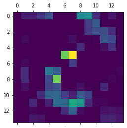

```python
img_path = "/content/drive/MyDrive/test/Deserts/1.png"

img_size = (224,224)

# Prepare image
img_array = preprocess_input(get_img_array(img_path, size=img_size))

# Remove last layer's softmax
model.layers[-1].activation = None

# Print what the top predicted class is
preds = model.predict(img)

# Generate class activation heatmap
heatmap = make_gradcam_heatmap(img, model, last_conv_layer_name)

# Display heatmap
plt.matshow(heatmap)
plt.show()

plt.savefig("Figure 6b.svg",format="svg",dpi=300)
```

**Creating the same for a plains sunflower image from test data**

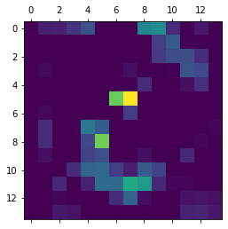

```python
img_path = "/content/drive/MyDrive/test/Plains/10.png"

img_size = (224,224)

# Prepare image
img_array = preprocess_input(get_img_array(img_path, size=img_size))

# Remove last layer's softmax
model.layers[-1].activation = None

# Print what the top predicted class is
preds = model.predict(img)
#print("Predicted:", decode_predictions(preds, top=1)[0])

# Generate class activation heatmap
heatmap = make_gradcam_heatmap(img, model, last_conv_layer_name)

# Display heatmap
plt.matshow(heatmap)
plt.show()

plt.savefig("Figure 6d.svg",format="svg",dpi=300)
```

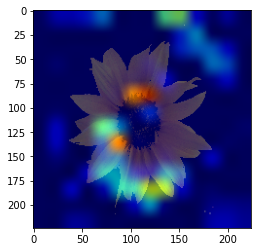

```python
#from IPython.display import Image, display
import matplotlib.cm as cm
img = load_img('/content/drive/MyDrive/test/Deserts/1.png', target_size=(224, 224)) #VGG user 224 as input

# convert the image to an array
img = img_to_array(img)


# Rescale heatmap to a range 0-255
heatmap = np.uint8(255 * heatmap)

# Use jet colormap to colorize heatmap
jet = cm.get_cmap("jet")

# Use RGB values of the colormap
jet_colors = jet(np.arange(256))[:, :3]
jet_heatmap = jet_colors[heatmap]

# Create an image with RGB colorized heatmap
jet_heatmap = array_to_img(jet_heatmap)
jet_heatmap = jet_heatmap.resize((img.shape[1], img.shape[0]))
jet_heatmap = img_to_array(jet_heatmap)

alpha = 1.6


#Superimpose the heatmap on original image
superimposed_img = jet_heatmap * alpha + img


superimposed_img = array_to_img(superimposed_img)

plt.imshow(superimposed_img)

plt.savefig("Figure 7b.svg",format="svg",dpi=300)

#cam_path = "desert_cam.svg"

# Save the superimposed image
#superimposed_img.save(cam_path)

# Display Grad CAM
#display(Image(cam_path))
```

**Same thing, but for the plains**

[figure not shown]

```python
#from IPython.display import Image, display

img = load_img('/content/drive/MyDrive/test/Plains/10.png', target_size=(224, 224)) #VGG user 224 as input

# convert the image to an array
img = img_to_array(img)


# Rescale heatmap to a range 0-255
heatmap = np.uint8(255 * heatmap)

# Use jet colormap to colorize heatmap
jet = cm.get_cmap("jet")

# Use RGB values of the colormap
jet_colors = jet(np.arange(256))[:, :3]
jet_heatmap = jet_colors[heatmap]

# Create an image with RGB colorized heatmap
jet_heatmap = array_to_img(jet_heatmap)
jet_heatmap = jet_heatmap.resize((img.shape[1], img.shape[0]))
jet_heatmap = img_to_array(jet_heatmap)

alpha = 1.6


#Superimpose the heatmap on original image
superimposed_img = jet_heatmap * alpha + img


superimposed_img = array_to_img(superimposed_img)

plt.imshow(superimposed_img)

plt.savefig("Figure 7d.svg",format="svg",dpi=300)
```